Visualizing a unique Numeric variable

*A few data analytics ideas from Data-to-Viz.com*

This document gives a few suggestions to analyse a dataset composed by a unique numeric variable.  
It considers the night price of about 10,000 [Airbnb](https://www.airbnb.fr) appartements on the French Riviera in France.  
This example dataset has been downloaded from the [Airbnb website](http://insideairbnb.com/get-the-data.html) and is available on this [Github repository](https://github.com/holtzy/data_to_viz/tree/master/Example_dataset). Basically it looks like the table beside.

```r
# Libraries
library(tidyverse)
library(hrbrthemes)
library(kableExtra)
options(knitr.table.format = "html")

# Load dataset from github
data <- read.table("https://raw.githubusercontent.com/holtzy/data_to_viz/master/Example_dataset/1_OneNum.csv", header=TRUE)

# show data
data %>% head(6) %>% kable() %>%
  kable_styling(bootstrap_options = "striped", full_width = F)
```

| price |
| --- |
| 75 |
| 104 |
| 369 |
| 300 |
| 92 |
| 64 |

# 1 Histogram

The most common way to represent a unique numeric variable is probably to produce a histogram. Basically, the numeric variable is cut in several `bins`: between 0 and 10 euros a night, between 10 and 20 and so on. This is represented on the X axis. Then, the number of appartment per bin is counted and represented by the Y axis.

Here, it appears that about 500 appartments have a price between 80 and 90 euros. A histogram is a convenient way to visualize the data: it allows to understand its `distribution`.

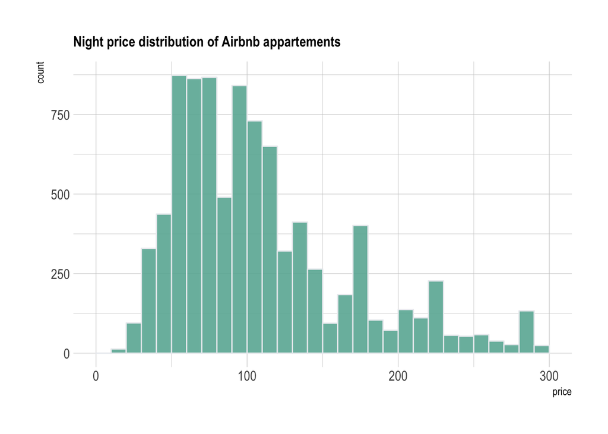

```r
data %>%
  filter( price<300 ) %>%
  ggplot( aes(x=price)) +
    stat_bin(breaks=seq(0,300,10), fill="#69b3a2", color="#e9ecef", alpha=0.9) +
    ggtitle("Night price distribution of Airbnb appartements") +
    theme_ipsum() +
    theme(
      plot.title = element_text(size=12)
    )
```

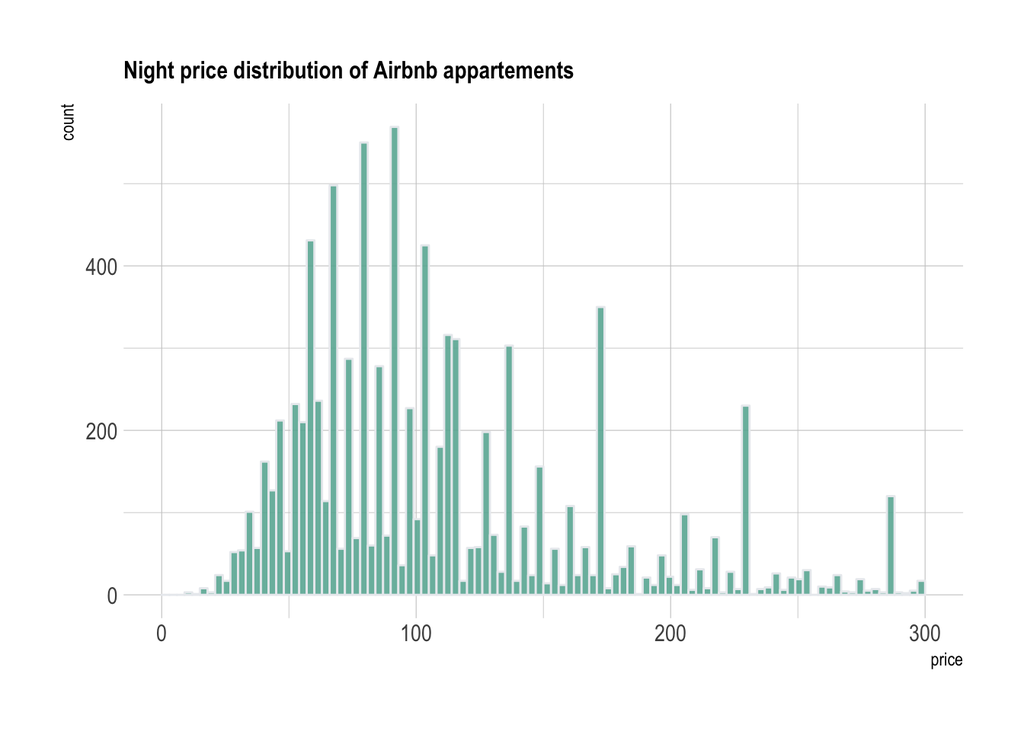

```r
data %>%
  filter( price<300 ) %>%
  ggplot( aes(x=price)) +
    stat_bin(breaks=seq(0,300,3), fill="#69b3a2", color="#e9ecef", alpha=0.9) +
    ggtitle("Night price distribution of Airbnb appartements") +
    theme_ipsum() +
    theme(
      plot.title = element_text(size=12)
    )
```

There is a huge difference difference between these 2 histograms. Actually a few values are over represented in the dataset (like 58, 64, 69, 75, 80..).This is definitely a signal that you want to understand when analysing your dataset.

# 2 Density

A variation of the histogram is the density plot, which is basically a smoothed version of the histogram. It represents a `kernel density estimate` of the variable. As seen for the bin size of the histogram, it is important to try several values for the `bandwidth` argument for the same reason:

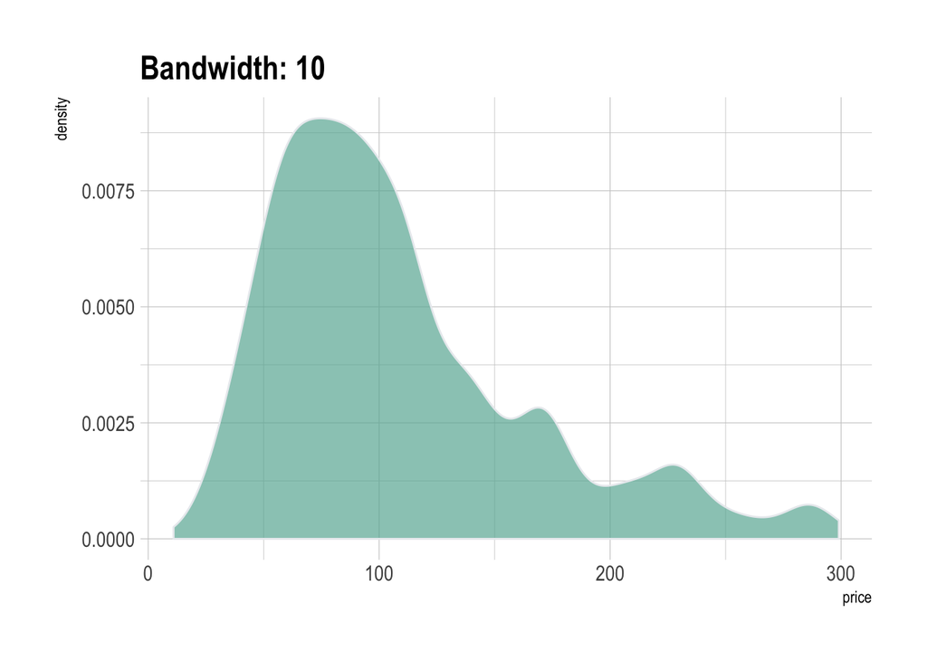

```r
data %>%
  filter( price<300 ) %>%
  ggplot( aes(x=price)) +
    geom_density(fill="#69b3a2", color="#e9ecef", alpha=0.7, bw=10) +
    ggtitle("Bandwidth: 10") +
    theme_ipsum()
```

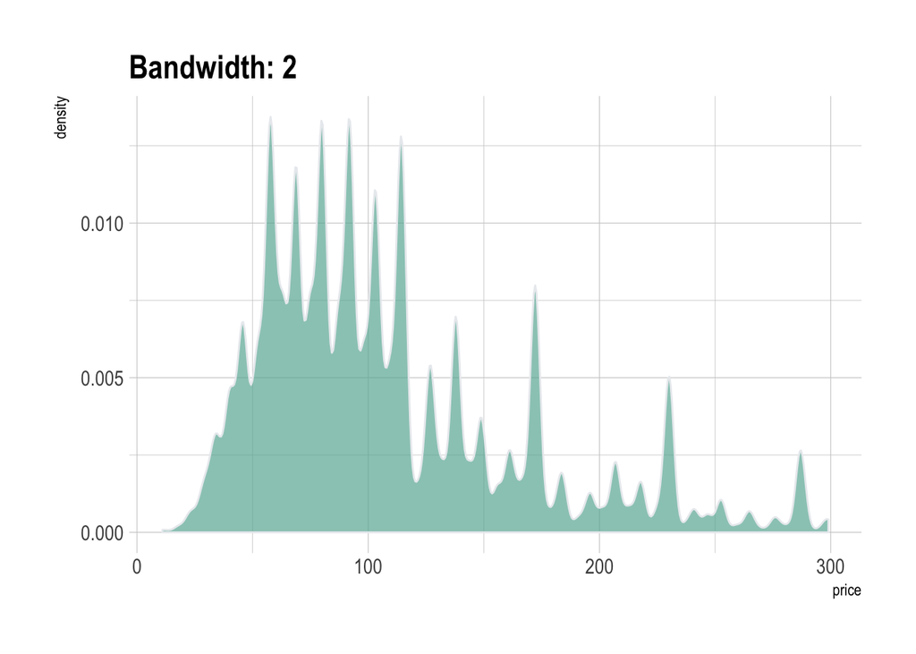

```r
data %>%
  filter( price<300 ) %>%
  ggplot( aes(x=price)) +
    geom_density(fill="#69b3a2", color="#e9ecef", alpha=0.7, bw=2) +
    ggtitle("Bandwidth: 2") +
    theme_ipsum()
```

A work by [Yan Holtz](https://github.com/holtzy/) for data-to-viz.com